# Reproducible Research Project

Elbrus Gasimov, Gunneet Singh & Muhammad Usman

5/14/2022

# Introduction

This project is composed of two sections. First, it deals in reproducing original results of the study and second we will replicate same approach on another data set with some improvements which have been explained in the second section.

### Topic and Data description

This project deals in “Human Development and its effects on Economic Growth”. The data set and variables used in this study spread over from 1990-2015 and includes only 5 African countries which are Kenya, Tanzania, Rwanda, Ghana and Cote d’Voire. Variables used in this study are: GDP is the dependent variable, Human Development Index (HDI) measured in percentage as the variable of interest with Inflation (INF) proxied as Consumer price index measured in percentage, Capital (CAP) proxied as Government Capital formation measured in % of GDP, Aid (AID) proxied as official development assistant measured in current USD, Investment (INV) proxied as foreign direct investment measured as (% of GDP) and Labour (LAB) as control variables. Data was retrieved from world bank and world development indicators (WDI) repositories.

## Part I Reproducibility

This part of project contains results of original study. We tried to produce original results. However we confronted with some issues in producing original results. They are discussed below step by step. Lets first load required libraries and then data set

```r
library(tidyverse)
library("readxl")
library("lmtest")
library("MASS")
library("sandwich")
library("zoo")
library("car")
library("lmtest")
library("Formula")
library("plm")
library("stargazer")
library("aod")
```

```r
data <- read_excel("data.xlsx") #loading the required data set
head(data) # looking at the first 5 observations
```

```
## # A tibble: 6 x 9
##   Country  Year    INV         GDP   GCF   INF         AID      LAB   HDI
##   <chr>   <dbl>  <dbl>       <dbl> <dbl> <dbl>       <dbl>    <dbl> <dbl>
## 1 Kenya    1990 0.666  8572359163.  24.2 17.8  1181290039.  8832294 0.482
## 2 Kenya    1991 0.231  8151479004.  21.0 20.1   916460022.  9181663 0.48
## 3 Kenya    1992 0.0775 8209129172.  16.9 27.3   884919983.  9552647 0.476
## 4 Kenya    1993 2.53   5751789915.  17.6 46.0   915630005.  9940305 0.472
## 5 Kenya    1994 0.104  7148145376.  19.3 28.8   677869995. 10335948 0.469
## 6 Kenya    1995 0.467  9046326060.  21.8  1.55  733090027. 10733809 0.468
```

Firstly, the original study took log transformations to have more normally distributed data of the following variables and then applied panel models (random and fixed effects).

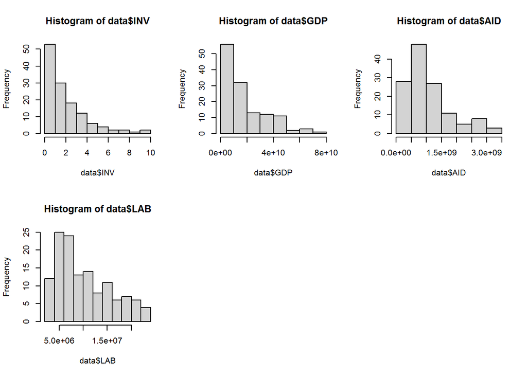

```r
#visualizing distributions of not normally distributed features and taking log transformations
par(mfrow=c(2,3))
hist(data$INV)
hist(data$GDP)
hist(data$AID)
hist(data$LAB)

#log transformations
data$INV<-log(data$INV)
data$GDP<-log(data$GDP)
data$AID<-log(data$AID)
data$LAB<-log(data$LAB)

#after log transformations more normally distributed data
par(mfrow=c(2,3))
```

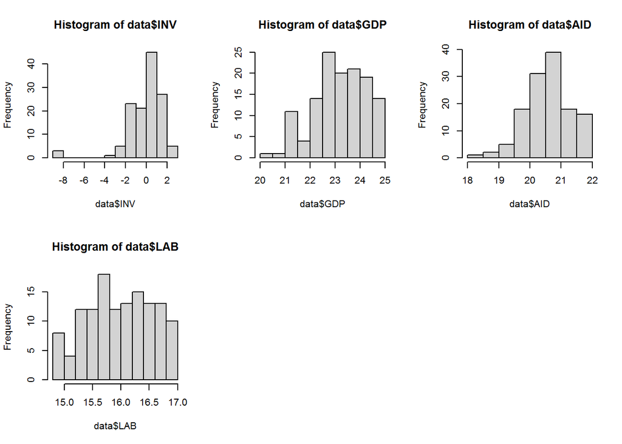

```r
hist(data$INV)
hist(data$GDP)
hist(data$AID)
hist(data$LAB)
```

```r
# Estimating fixed effects model
fixed <- plm(GDP~INV+GCF+INF+AID+LAB+HDI,
            data=data, index=c("Country", "Year"), model="within")
summary(fixed)
```

```
## Oneway (individual) effect Within Model
##
## Call:
## plm(formula = GDP ~ INV + GCF + INF + AID + LAB + HDI, data = data,
##     model = "within", index = c("Country", "Year"))
##
## Balanced Panel: n = 5, T = 26, N = 130
##
## Residuals:
##       Min.    1st Qu.     Median    3rd Qu.       Max.
## -0.7369005 -0.1625111  0.0082231  0.1435287  0.7246059
##
## Coefficients:
##       Estimate Std. Error t-value  Pr(>|t|)
## INV  0.0255825  0.0166637  1.5352 0.1273826
## GCF  0.0022030  0.0057482  0.3833 0.7022147
## INF -0.0104667  0.0029137 -3.5923 0.0004777 ***
## AID  0.1527935  0.0468970  3.2581 0.0014622 **
## LAB  2.5796587  0.2371816 10.8763 < 2.2e-16 ***
## HDI  0.2832158  0.7472817  0.3790 0.7053672
## ---
## Signif. codes:  0 '***' 0.001 '**' 0.01 '*' 0.05 '.' 0.1 ' ' 1
##
## Total Sum of Squares:    68.212
## Residual Sum of Squares: 7.7488
## R-Squared:      0.8864
## Adj. R-Squared: 0.87686
## F-statistic: 154.759 on 6 and 119 DF, p-value: < 2.22e-16
```

## Part II Replicability

We will now replicate the same study but on different data set and keeping in mind all the steps that are involved in performing panel models(Random and Fixed Effects). After loading the data following are the complete set of steps that we would like to perform:

1. Checking distributions of features and taking log transformations if required
2. Fixed effects model
3. Random effects model
4. Ols model
5. Test for the selection of best model among the above mentioned
6. Test for time and cross sectional effects
7. General to specific approach to identify the significant variables
8. Diagnostic tests for serial correlation and heteroskedasticity
9. Variance-Covariance method to control both heteroskedasticity and autocorrelation
10. Conclusions

Lets first load the data set

```r
my_data <- read.csv("rep_data.csv")# loading csv file
head(my_data) # checking first 5 observations
```

```
##      Country Year         INV       INF      GCF          GDP   HDI      LAB
## 1 Bangladesh 2006 0.005005382  6.765261 26.14415  71819083684 0.513 54083636
## 2 Bangladesh 2007 0.168647558  9.106985 26.17850  79611888213 0.520 54954286
## 3 Bangladesh 2008 0.208073847  8.901945 26.20227  91631278239 0.523 55799460
## 4 Bangladesh 2009 0.176456993  5.423472 26.20606 102000000000 0.535 56639145
## 5 Bangladesh 2010 0.057635858  8.126676 26.24666 115000000000 0.545 57493263
## 6 Bangladesh 2011 0.231218249 11.395165 27.42097 129000000000 0.557 58436990
##          AID
## 1 1027819946
## 2 1308520020
## 3 1765829956
## 4 1082760010
## 5 1327329956
## 6 1437520020
```

Our data set consist of same features but spreads over from 2006 to 2016 and for total number of 14 countries. Before checking the distributions of our variables lets firts check for missing values.

```r
# Checking if any of the variables has NA's using sapply function
sapply(my_data, function(x) sum(is.na(x)))
```

```
## Country    Year     INV     INF     GCF     GDP     HDI     LAB     AID
##       0       0       0       0       0       0       0       0       0
```

We have no missing values so lets visualize distributions.

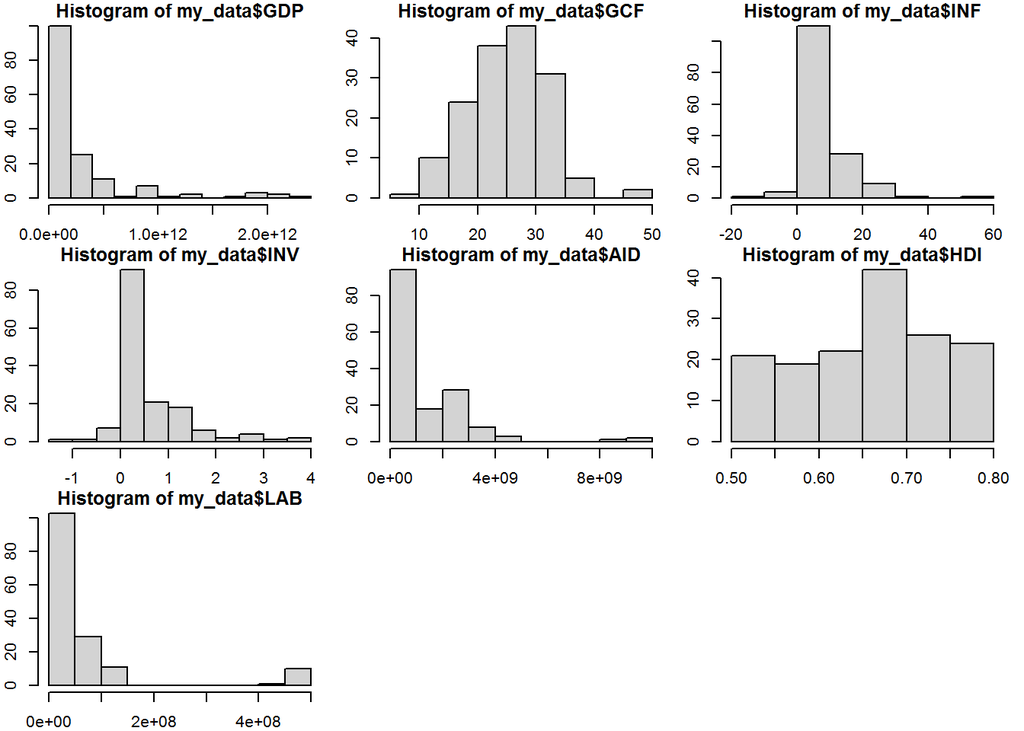

```r
par(mfrow=c(3,3)) #allows us to create a matrix of plots
par(mar=c(2,2,1,1))
hist(my_data$GDP)
hist(my_data$GCF)
hist(my_data$INF)
hist(my_data$INV)
hist(my_data$AID)
hist(my_data$HDI)
hist(my_data$LAB)
```

Apart from GCF and HDI all other distributions are either right skewed or left skewed. Lets take log transformations and see if it helps our cause.

```r
#we have small values in our data set and if we perform log transformations we get negative values
#to avoid this we add positive absolute value to few of the features
my_data$GDP<-log(my_data$GDP)
my_data$INV<-log(my_data$INV+5)
my_data$INF<-log(my_data$INF+15)
my_data$LAB<-log(my_data$LAB)
my_data$AID<-log(my_data$AID)
```

lets now check our distributions after taking log transformations.

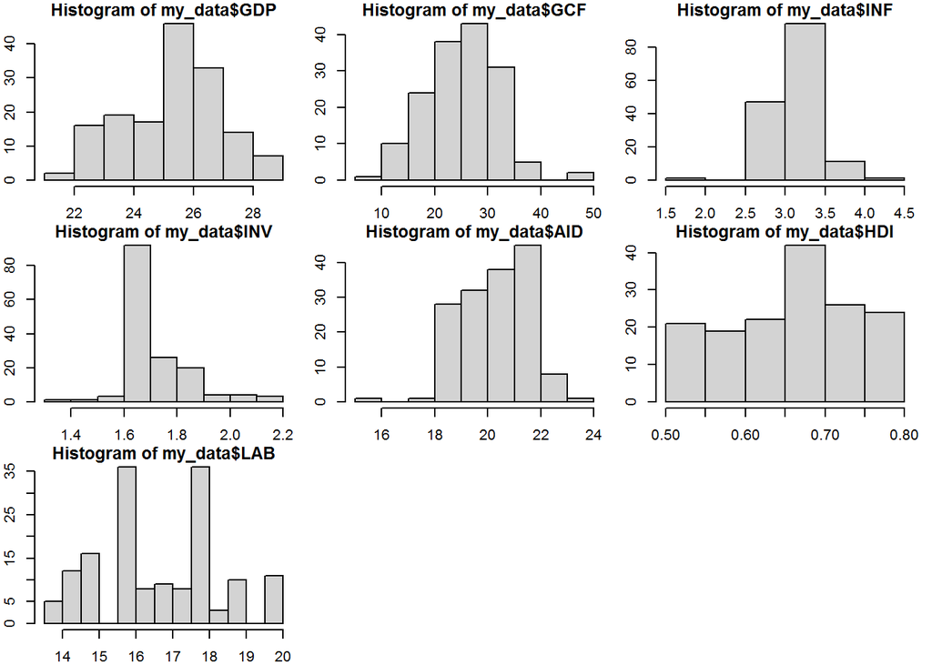

```r
#visualizing log transformed features
par(mfrow=c(3,3))
par(mar=c(2,2,1,1))
hist(my_data$GDP)
hist(my_data$GCF)
hist(my_data$INF)
hist(my_data$INV)
hist(my_data$AID)
hist(my_data$HDI)
hist(my_data$LAB)
```

The above graphs show that log transformation does help as now data looks in better shape then without log transformation. The next step is to perform panel modeling.

```r
# Fixed effects model
fixed <- plm(GDP~INV+INF+GCF+HDI+LAB+AID,
            data=my_data, index=c("Country", "Year"), model="within")
summary(fixed)
```

```
## Oneway (individual) effect Within Model
##
## Call:
## plm(formula = GDP ~ INV + INF + GCF + HDI + LAB + AID, data = my_data,
##     model = "within", index = c("Country", "Year"))
##
## Balanced Panel: n = 14, T = 11, N = 154
##
## Residuals:
##       Min.    1st Qu.     Median    3rd Qu.       Max.
## -0.4189160 -0.0860369  0.0093419  0.1081554  0.3503269
##
## Coefficients:
##       Estimate Std. Error t-value  Pr(>|t|)
## INV -0.0806106  0.1719925 -0.4687   0.64006
## INF  0.0117286  0.0580358  0.2021   0.84015
## GCF  0.0081642  0.0033962  2.4039   0.01759 *
## HDI 10.2764651  0.8356244 12.2979 < 2.2e-16 ***
## LAB  1.5591199  0.2173253  7.1741 4.466e-11 ***
## AID -0.0168746  0.0251039 -0.6722   0.50262
## ---
## Signif. codes:  0 '***' 0.001 '**' 0.01 '*' 0.05 '.' 0.1 ' ' 1
##
## Total Sum of Squares:    16.638
## Residual Sum of Squares: 3.538
## R-Squared:      0.78736
## Adj. R-Squared: 0.75721
## F-statistic: 82.6955 on 6 and 134 DF, p-value: < 2.22e-16
```

The output of the model clearly suggests that only three out of the six variables are statistically significant at the 5% level of significance. Comparing the results with those of the original study, there is a difference in the variables which are significant. Unlike the previous dataset, HDI and GCF are significant for the current data.

```r
# Creating random effects model

random <-plm(GDP~INV+INF+GCF+HDI+LAB+AID,
            data=my_data, index=c("Country", "Year"), model="random")
summary(random)
```

```
## Oneway (individual) effect Random Effect Model
##    (Swamy-Arora's transformation)
##
## Call:
## plm(formula = GDP ~ INV + INF + GCF + HDI + LAB + AID, data = my_data,
##     model = "random", index = c("Country", "Year"))
##
## Balanced Panel: n = 14, T = 11, N = 154
##
## Effects:
##                  var std.dev share
## idiosyncratic 0.0264  0.1625 0.066
## individual    0.3745  0.6120 0.934
## theta: 0.9202
##
## Residuals:
##      Min.   1st Qu.    Median   3rd Qu.      Max.
## -0.423823 -0.093824  0.010127  0.102599  0.465250
##
## Coefficients:
##               Estimate Std. Error z-value Pr(>|z|)
## (Intercept) -1.2189164  1.6029235 -0.7604  0.44700
## INV         -0.0769950  0.1719326 -0.4478  0.65428
## INF         -0.0167589  0.0574177 -0.2919  0.77038
## GCF          0.0075323  0.0034252  2.1991  0.02787 *
## HDI         10.9088422  0.6704886 16.2700  < 2e-16 ***
## LAB          1.1696835  0.0900275 12.9925  < 2e-16 ***
## AID         -0.0092359  0.0249463 -0.3702  0.71121
## ---
## Signif. codes:  0 '***' 0.001 '**' 0.01 '*' 0.05 '.' 0.1 ' ' 1
##
## Total Sum of Squares:    19.187
## Residual Sum of Squares: 3.9906
## R-Squared:      0.79201
## Adj. R-Squared: 0.78352
## Chisq: 559.765 on 6 DF, p-value: < 2.22e-16
```

Like fixed effects model, this model also suggests that only 3 and that also the same variables are significant.

```r
# Creating OLS model

OLS <-plm(GDP~INV+INF+GCF+HDI+LAB+AID,
            data=my_data, index=c("Country", "Year"), model="pooling")
summary(OLS)
```

```
## Pooling Model
##
## Call:
## plm(formula = GDP ~ INV + INF + GCF + HDI + LAB + AID, data = my_data,
##     model = "pooling", index = c("Country", "Year"))
##
## Balanced Panel: n = 14, T = 11, N = 154
##
## Residuals:
##      Min.   1st Qu.    Median   3rd Qu.      Max.
## -1.087037 -0.327861  0.021654  0.295434  1.694676
##
## Coefficients:
##               Estimate Std. Error t-value  Pr(>|t|)
## (Intercept)  1.0437498  1.4475996  0.7210   0.47204
## INV         -0.3452364  0.3545729 -0.9737   0.33182
## INF         -0.0012209  0.1559493 -0.0078   0.99376
## GCF         -0.0316012  0.0067437 -4.6860 6.293e-06 ***
## HDI         10.0249714  0.6623900 15.1345 < 2.2e-16 ***
## LAB          1.0632143  0.0291346 36.4932 < 2.2e-16 ***
## AID          0.0644316  0.0386378  1.6676   0.09753 .
## ---
## Signif. codes:  0 '***' 0.001 '**' 0.01 '*' 0.05 '.' 0.1 ' ' 1
##
## Total Sum of Squares:    416.79
## Residual Sum of Squares: 39.806
## R-Squared:      0.90449
## Adj. R-Squared: 0.9006
## F-statistic: 232.027 on 6 and 147 DF, p-value: < 2.22e-16
```

It has become almost certain that the factors “GCF”, “HDI”, and “LAB” are statiscally important and hence impacts GDP more than any other variables.

```r
# Individual effects for random effects

plmtest(OLS, type=c("bp"))
```

```
##
##  Lagrange Multiplier Test - (Breusch-Pagan) for balanced panels
##
## data:  GDP ~ INV + INF + GCF + HDI + LAB + AID
## chisq = 462.7, df = 1, p-value < 2.2e-16
## alternative hypothesis: significant effects
```

As the p-value is less than the 5% significance level, it means we reject the null hypothesis that all individual effects are insignificant. Clearly, it means Random effects model is better than an OLS model.

```r
# Individual effects for fixed effects

pFtest(fixed, OLS)
```

```
##
##  F test for individual effects
##
## data:  GDP ~ INV + INF + GCF + HDI + LAB + AID
## F = 105.66, df1 = 13, df2 = 134, p-value < 2.2e-16
## alternative hypothesis: significant effects
```

As the p-value is less than the 5% significance level, it means we reject the null hypothesis that all individual effects are insignificant. Clearly, it means Fixed effects model is better than an OLS model.

Let us now finally check which one among fixed and random is the best model for our analysis using Hausman Specification test.

```r
# Hausman Specification test

phtest(fixed, random)
```

```
##
##  Hausman Test
##
## data:  GDP ~ INV + INF + GCF + HDI + LAB + AID
## chisq = 5.0234, df = 6, p-value = 0.5408
## alternative hypothesis: one model is inconsistent
```

As the p-value is very big in comparison with the 5% significance level, we fail to reject the null hypothesis of the Hausman test, which means the Random effects model is most suitable for the study.

```r
# Taking into consideration the time & crossectional effects

random.time <- plm(GDP~INV+INF+GCF+HDI+LAB+AID,
            data=my_data, index=c("Country", "Year"), model="random", effect = "twoways")
summary(random.time)
```

```
## Twoways effects Random Effect Model
##    (Swamy-Arora's transformation)
##
## Call:
## plm(formula = GDP ~ INV + INF + GCF + HDI + LAB + AID, data = my_data,
##     effect = "twoways", model = "random", index = c("Country",
##         "Year"))
##
## Balanced Panel: n = 14, T = 11, N = 154
##
## Effects:
##                    var  std.dev share
## idiosyncratic 0.014798 0.121648 0.038
## individual    0.375587 0.612852 0.953
## time          0.003881 0.062296 0.010
## theta: 0.9403 (id) 0.5373 (time) 0.5369 (total)
##
## Residuals:
##       Min.    1st Qu.     Median    3rd Qu.       Max.
## -0.3403306 -0.0811603  0.0085183  0.0913005  0.3886307
##
## Coefficients:
##                Estimate  Std. Error z-value  Pr(>|z|)
## (Intercept)  1.35857411  1.84858789  0.7349  0.462385
## INV         -0.13880898  0.14322251 -0.9692  0.332453
## INF         -0.10679631  0.05224128 -2.0443  0.040925 *
## GCF          0.00728665  0.00278927  2.6124  0.008991 **
## HDI          8.96072982  0.87516181 10.2389 < 2.2e-16 ***
## LAB          1.10536207  0.09786201 11.2951 < 2.2e-16 ***
## AID         -0.00073716  0.02063169 -0.0357  0.971498
## ---
## Signif. codes:  0 '***' 0.001 '**' 0.01 '*' 0.05 '.' 0.1 ' ' 1
##
## Total Sum of Squares:    6.647
## Residual Sum of Squares: 2.6138
## R-Squared:      0.60676
## Adj. R-Squared: 0.59071
## Chisq: 226.821 on 6 DF, p-value: < 2.22e-16
```

We will be considering this two way random effects model for further analysis.

```r
# General-to-specific procedure

# General model

random1 <-plm(GDP~INV+INF+GCF+HDI+LAB+AID,
            data=my_data, index=c("Country", "Year"), model="random", effect = "twoways")
summary(random1)
```

```
## Twoways effects Random Effect Model
##    (Swamy-Arora's transformation)
##
## Call:
## plm(formula = GDP ~ INV + INF + GCF + HDI + LAB + AID, data = my_data,
##     effect = "twoways", model = "random", index = c("Country",
##         "Year"))
##
## Balanced Panel: n = 14, T = 11, N = 154
##
## Effects:
##                    var  std.dev share
## idiosyncratic 0.014798 0.121648 0.038
## individual    0.375587 0.612852 0.953
## time          0.003881 0.062296 0.010
## theta: 0.9403 (id) 0.5373 (time) 0.5369 (total)
##
## Residuals:
##       Min.    1st Qu.     Median    3rd Qu.       Max.
## -0.3403306 -0.0811603  0.0085183  0.0913005  0.3886307
##
## Coefficients:
##                Estimate  Std. Error z-value  Pr(>|z|)
## (Intercept)  1.35857411  1.84858789  0.7349  0.462385
## INV         -0.13880898  0.14322251 -0.9692  0.332453
## INF         -0.10679631  0.05224128 -2.0443  0.040925 *
## GCF          0.00728665  0.00278927  2.6124  0.008991 **
## HDI          8.96072982  0.87516181 10.2389 < 2.2e-16 ***
## LAB          1.10536207  0.09786201 11.2951 < 2.2e-16 ***
## AID         -0.00073716  0.02063169 -0.0357  0.971498
## ---
## Signif. codes:  0 '***' 0.001 '**' 0.01 '*' 0.05 '.' 0.1 ' ' 1
##
## Total Sum of Squares:    6.647
## Residual Sum of Squares: 2.6138
## R-Squared:      0.60676
## Adj. R-Squared: 0.59071
## Chisq: 226.821 on 6 DF, p-value: < 2.22e-16
```

According to the results INV and AID are not statistically significant. The variable AID has the maximum pvalue of around 0.97

```r
# General model without AID

random2 <-plm(GDP~INV+INF+GCF+HDI+LAB,
            data=my_data, index=c("Country", "Year"), model="random", effect = "twoways")
summary(random2)
```

```
## Twoways effects Random Effect Model
##    (Swamy-Arora's transformation)
##
## Call:
## plm(formula = GDP ~ INV + INF + GCF + HDI + LAB, data = my_data,
##     effect = "twoways", model = "random", index = c("Country",
##         "Year"))
##
## Balanced Panel: n = 14, T = 11, N = 154
##
## Effects:
##                    var  std.dev share
## idiosyncratic 0.014728 0.121359 0.042
## individual    0.334729 0.578558 0.947
## time          0.003996 0.063211 0.011
## theta: 0.9369 (id) 0.5435 (time) 0.543 (total)
##
## Residuals:
##       Min.    1st Qu.     Median    3rd Qu.       Max.
## -0.3380088 -0.0800792  0.0072216  0.0944459  0.3925236
##
## Coefficients:
##               Estimate Std. Error z-value  Pr(>|z|)
## (Intercept)  1.5088509  1.7791198  0.8481  0.396389
## INV         -0.1403977  0.1402600 -1.0010  0.316836
## INF         -0.1076655  0.0521857 -2.0631  0.039101 *
## GCF          0.0072514  0.0027638  2.6237  0.008698 **
## HDI          8.9135467  0.8702142 10.2429 < 2.2e-16 ***
## LAB          1.0976956  0.0935973 11.7279 < 2.2e-16 ***
## ---
## Signif. codes:  0 '***' 0.001 '**' 0.01 '*' 0.05 '.' 0.1 ' ' 1
##
## Total Sum of Squares:    6.731
## Residual Sum of Squares: 2.623
## R-Squared:      0.61031
## Adj. R-Squared: 0.59715
## Chisq: 231.793 on 5 DF, p-value: < 2.22e-16
```

Now we are left with only one statistically insignificant variable which is INV, which has the pvalue around 0.32

```r
# General model without INV

random3 <-plm(GDP~INF+GCF+HDI+LAB,
            data=my_data, index=c("Country", "Year"), model="random", effect = "twoways")
summary(random3)
```

```
## Twoways effects Random Effect Model
##    (Swamy-Arora's transformation)
##
## Call:
## plm(formula = GDP ~ INF + GCF + HDI + LAB, data = my_data, effect = "twoways",
##     model = "random", index = c("Country", "Year"))
##
## Balanced Panel: n = 14, T = 11, N = 154
##
## Effects:
##                   var std.dev share
## idiosyncratic 0.01483 0.12177 0.046
## individual    0.30688 0.55396 0.945
## time          0.00317 0.05630 0.010
## theta: 0.9339 (id) 0.4995 (time) 0.4991 (total)
##
## Residuals:
##       Min.    1st Qu.     Median    3rd Qu.       Max.
## -0.3511250 -0.0850166  0.0074111  0.0960665  0.3978226
##
## Coefficients:
##               Estimate Std. Error z-value Pr(>|z|)
## (Intercept)  0.9633795  1.7047068  0.5651  0.57199
## INF         -0.1046988  0.0526976 -1.9868  0.04695 *
## GCF          0.0069160  0.0027931  2.4761  0.01328 *
## HDI          9.2426416  0.8368559 11.0445  < 2e-16 ***
## LAB          1.1029886  0.0909834 12.1230  < 2e-16 ***
## ---
## Signif. codes:  0 '***' 0.001 '**' 0.01 '*' 0.05 '.' 0.1 ' ' 1
##
## Total Sum of Squares:    7.4976
## Residual Sum of Squares: 2.7394
## R-Squared:      0.63463
## Adj. R-Squared: 0.62482
## Chisq: 258.808 on 4 DF, p-value: < 2.22e-16
```

All of our variables are statistically significant at 5 percent level of significance.

```r
# Performing some Diagnostic tests

# Testing for serial correlation

pbgtest(random3)
```

```
##
##  Breusch-Godfrey/Wooldridge test for serial correlation in panel models
##
## data:  GDP ~ INF + GCF + HDI + LAB
## chisq = 89.069, df = 11, p-value = 2.536e-14
## alternative hypothesis: serial correlation in idiosyncratic errors
```

As per Breusch-Godfrey/Wooldridge test, the p value comes out to be almost 0, which means we reject our Null Hypothesis. This implies there exist serial correlation in idiosyncratic errors.

```r
# Testing for heteroskedasticity

bptest(random3, studentize=T)
```

```
##
##  studentized Breusch-Pagan test
##
## data:  random3
## BP = 4.9402, df = 4, p-value = 0.2935
```

According the studentized Breusch-Pagan test, there is no heteroscedasticity present in thee data, as our pvalue is way more than 5 percent level of significance.

Clearly, the model has serial correlation but no heteroskedasticity.

```r
# Using Variance-Covariance method to control both heteroskedasticity and autocorrelation:

coeftest(random3, vcov.=vcovHC(random3, method="white1", type="HC0", cluster="group"))
```

```
##
## t test of coefficients:
##
##               Estimate Std. Error t value Pr(>|t|)
## (Intercept)  0.9633795  1.6110800  0.5980  0.55077
## INF         -0.1046988  0.0543019 -1.9281  0.05575 .
## GCF          0.0069160  0.0030231  2.2878  0.02356 *
## HDI          9.2426416  0.8203237 11.2671  < 2e-16 ***
## LAB          1.1029886  0.0788161 13.9945  < 2e-16 ***
## ---
## Signif. codes:  0 '***' 0.001 '**' 0.01 '*' 0.05 '.' 0.1 ' ' 1
```

```r
# Creating the Publication quality table

stargazer(random1, random2, random3, title="Quality table", align=TRUE, type="text")
```

```
##
## Quality table
## =============================================
##                    Dependent variable:
##              --------------------------------
##                            GDP
##                 (1)        (2)        (3)
## ---------------------------------------------
## INV            -0.139     -0.140
##               (0.143)    (0.140)
##
## INF           -0.107**   -0.108**   -0.105**
##               (0.052)    (0.052)    (0.053)
##
## GCF           0.007***   0.007***   0.007**
##               (0.003)    (0.003)    (0.003)
##
## HDI           8.961***   8.914***   9.243***
##               (0.875)    (0.870)    (0.837)
##
## LAB           1.105***   1.098***   1.103***
##               (0.098)    (0.094)    (0.091)
##
## AID            -0.001
##               (0.021)
##
## Constant       1.359      1.509      0.963
##               (1.849)    (1.779)    (1.705)
##
## ---------------------------------------------
## Observations    154        154        154
## R2             0.607      0.610      0.635
## Adjusted R2    0.591      0.597      0.625
## F Statistic  226.821*** 231.793*** 258.808***
## =============================================
## Note:             *p<0.1; **p<0.05; ***p<0.01
```

## Conclusions

This project focuses on reproducability and replicability of selected research on new data set. For reproducability part we could not able to produce original results. We identified few reasons for non reproducability. First of all, starting with variable selection and transformations; the authors did not visualized and mention any transformations. As these models work best for normally distributed data. Second, to apply panel models (Random and fixed effects) one of the other criteria is to meet this condition; N > T (number of countries must be greater then number of years). Third, they neglected ordinary least square and considered only random and fixed effects. Furthermore, they did not test for time and cross sectional effects. Issues related to autocorrelation and heteroscedasiticy were also neglected. These above mentioned steps are vital in performing panel models. For our part we applied all those steps and these might be the reasons we found contrasting results to original results.